# **Local Economic Conditions and Airbnb Prices: Evidence from the New York City Housing Market**

# 1. Project One

## 1.1 Introduction

The rapid expansion of the sharing economy has significantly transformed the tourism and accommodation industries. Among peer-to-peer accommodation platforms, Airbnb has become one of the most prominent examples, connecting homeowners who supply accommodation with travelers seeking short-term rentals. Since its founding in 2008, Airbnb has expanded rapidly across cities worldwide and has become an important component of urban tourism and local housing markets. As a result, understanding how prices are determined in short-term rental markets has become an increasingly important question for both researchers and policymakers.

A large body of literature has examined the determinants of Airbnb listing prices, primarily focusing on listing-level characteristics. Early studies based on hedonic pricing models show that factors such as room type, property features, amenities, and host attributes play a central role in shaping price variation, as they reflect differences in accommodation quality (Wang & Nicolau, 2017; Cai et al., 2019). In addition, online reputation signals, including ratings and review content, significantly influence consumers’ willingness to pay, highlighting the importance of information asymmetry in digital markets (Lin & Yang, 2024). More recent studies further demonstrate that pricing behavior is heterogeneous across listings and can vary depending on market conditions and dynamic pricing strategies (Leoni & Nilsson, 2021).

Beyond listing characteristics, a growing strand of literature emphasizes the importance of spatial and neighborhood factors. Airbnb prices often exhibit substantial spatial heterogeneity due to differences in accessibility, proximity to tourist attractions, and local amenities (Chica-Olmo et al., 2020; Perez-Sanchez et al., 2018). Spatial econometric analyses further show that Airbnb prices are spatially dependent, meaning that nearby listings and neighborhood conditions jointly influence pricing outcomes (Gyodi & Nawaro, 2021). In addition, recent research highlights the importance of incorporating geographic variation and nonlinear relationships when modeling Airbnb prices, particularly when using more flexible approaches such as machine learning methods (Jiang et al., 2023).

At a broader level, several studies examine the spatial distribution of Airbnb listings and its relationship with urban structure. These studies find that Airbnb activity is highly concentrated in areas with strong tourism demand, such as major cities, coastal regions, and locations with abundant secondary housing supply (Adamiak et al., 2019). Similarly, research on urban spatial patterns shows that the distribution of Airbnb listings is shaped by local amenities, cultural attractions, and urban structures, reflecting both demand-side and supply-side forces (Sun et al., 2022). These findings suggest that understanding Airbnb pricing requires considering not only individual listings but also the broader spatial and economic context.

At the same time, Airbnb is closely linked to the wider housing market. Existing research shows that the expansion of short-term rental platforms can affect housing rents and property prices, particularly in areas with high tourism intensity (Garcia-López et al., 2020). Other studies further highlight that Airbnb interacts with urban development and housing market dynamics, suggesting that its impact extends beyond the short-term rental market itself (Zhu & Liu, 2024). Moreover, recent evidence points to heterogeneous effects across neighborhoods, indicating that the impact of Airbnb depends on local economic and spatial conditions (Lee & Kim, 2023).

Despite these important contributions, two gaps remain in the literature. First, while existing studies often focus either on listing-level characteristics or on spatial distribution patterns, relatively few studies explicitly link neighborhood-level economic conditions—such as income, population density, and safety—to Airbnb pricing through housing market mechanisms. Second, although recent research increasingly adopts advanced empirical methods, there remains a need to integrate these approaches with a clear economic interpretation of demand and supply conditions.

Motivated by these gaps, this project investigates how neighborhood-level economic conditions are associated with Airbnb price levels in New York City, with housing market conditions serving as a key mechanism linking local economic environments to short-term rental prices. Using the NYC Airbnb 2019 dataset combined with borough-level economic indicators and neighborhood characteristics, the analysis examines how local economic environments, listing features, and spatial factors jointly shape Airbnb pricing.

By combining descriptive spatial analysis with regression analysis, and complementing these with machine learning approaches, this project provides a more comprehensive understanding of Airbnb pricing. The results highlight how local economic environments are reflected in price patterns through both demand-side factors, such as income and neighborhood attractiveness, and supply-side conditions, such as housing availability and listing composition.

## 1.2 Data Description & Cleaning

### 1.2.1 Original (Main) Dataset

The main dataset is the AB_NYC_2019 Airbnb dataset, which provides listing-level information on price, location, room type, and availability. The listing price is used as the outcome variable. Variables with high missing rates and limited relevance are removed, and the dataset is merged with borough-level economic data.

### 1.2.2 Other Dataset

Additional datasets are incorporated to capture neighborhood conditions. Census data provide population and land area, which are used to construct population density and GDP per capita. Income data are obtained from Tableau Public, and crime data from the NYPD are matched to listings using geographic coordinates.

### 1.2.3 Variable Choice

The outcome variable is listing price, Key explanatory variables include income, GDP per capita, population density, and crime rate. Listing-level variables such as availability, minimum nights, reviews, and room type are also used to proxy short-term rental supply tightness and listing activity.

The underlying mechanism is that neighborhood economic conditions shape Airbnb prices through both demand-side willingness to pay and supply-side housing market constraints. Higher-income and more economically productive neighborhoods are expected to face stronger demand, while differences in room type composition and availability reflect variation in effective housing supply for short-term rentals. Together, these factors help explain systematic differences in Airbnb prices across New York City.

## 1.3 Summary Statistics

### 1.3.1 Main Variables

```python
import pandas as pd
import numpy as np

df = pd.read_csv("AB_NYC_2019.csv")

# Import Basic NYC Neighbourhood-level Economic Indicators
nbh_data = pd.DataFrame({
    'neighbourhood_group':['Bronx', 'Brooklyn','Manhattan', 'Queens', 'Staten Island'],
    'Population':[1472654, 2736074, 1694251, 2405464, 495747],
    'Area':[109.2, 179.7, 58.7, 281.6, 149.0],
    'GDP_in_billion':[51.574, 125.867, 885.652, 122.288, 21.103]})

nbh_data['Pop_Density'] = nbh_data['Population'] / nbh_data['Area']
nbh_data['GDP_per_capita'] = nbh_data['GDP_in_billion'] / nbh_data["Population"] * 1e9
```

```python
# Import Neighbourhood Avg Income Data
Avg_Income = pd.read_csv("Average Households Income Across the Regions.csv")
Avg_Income = Avg_Income.rename(columns={
    "Householdsmean Income Dollars": "Avg Income",
    "Geographic Area Name": "neighbourhood_group"})

Avg_Income_2019 = Avg_Income.query('Year == 2019').copy()
Avg_Income_2019["neighbourhood_group"] = Avg_Income_2019["neighbourhood_group"].replace({
    "Kings County, New York": "Brooklyn",
    "Queens County, New York": "Queens",
    "Richmond County, New York": "Staten Island",
    "New York County, New York": "Manhattan",
    "Bronx County, New York": "Bronx"})

Avg_Income_2019 = Avg_Income_2019[["neighbourhood_group", "Avg Income"]]
nbh_data_m = pd.merge(nbh_data, Avg_Income_2019, on='neighbourhood_group')
```

```python
# Import Crime Dataset
import geopandas as gpd
cd = pd.read_csv("seven-major-felony-offenses-by-precinct-2000-2025.csv")

cd["PCT"] = cd["PCT"].ffill()
total_cd = cd[cd["CRIME"].str.contains("TOTAL", case=False, na=False)]
crime_2019 = total_cd[["PCT", "Count_Offences"]]

airbnb_geo = gpd.GeoDataFrame(df,geometry=gpd.points_from_xy(df.longitude, df.latitude),crs="EPSG:4326")
precincts = gpd.read_file("nyc_precincts.gpkg").to_crs("EPSG:4326")
```

```python
# Data Cleaning
airbnb_pct = gpd.sjoin(airbnb_geo, precincts[["Precinct", "geometry"]], how="left", predicate="within")

pct_match = airbnb_pct[["id", "Precinct"]].copy()
pct_match["Precinct"] = pd.to_numeric(pct_match["Precinct"], errors="coerce")

crime_2019 = crime_2019.copy()
crime_2019["PCT"] = pd.to_numeric(crime_2019["PCT"], errors="coerce")

df = df.merge(pct_match, on="id", how="left")
df = df.merge(crime_2019, left_on="Precinct", right_on="PCT", how="left")

df["Count_Offences"] = (
    df["Count_Offences"]
    .astype(str)
    .str.replace(",", "")
    .astype(float))

# Calculate crime rate (>1 means higher than avg, <1 means lower than avg)
df["crime_rate"] = df["Count_Offences"] / df["Count_Offences"].mean()

df = df.drop(columns=["last_review","reviews_per_month","Precinct"])

# Merge original dataframe & economic indicator data
df1 = df.merge(nbh_data_m, on="neighbourhood_group", how="left")

df1['Price_to_Income Ratio'] = df1['price']*365 / (df1['Avg Income'])
df1["log_price"] = np.log(df1["price"] + 1)
df1["avg_income_10k"] = df1["Avg Income"] / 10000
df1["gdp_10k"] = df1["GDP_per_capita"] / 10000
df1["density_1k"] = df1["Pop_Density"] / 1000
```

```python
from IPython.display import display, Latex
from stargazer.stargazer import Stargazer
from IPython.core.display import HTML
```

```python
# ==============================
# Table 1: Main Quantity Variables Summary
# ==============================
vars_table1 = [
    "price",
    "Avg Income",
    "GDP_per_capita",
    "Pop_Density",
    "Count_Offences",
    "availability_365",
    "minimum_nights",
    "number_of_reviews"]

tbl1 = df1[vars_table1].replace([np.inf, -np.inf], np.nan)
tbl1["price_income_ratio"] = tbl1["price"] * 365 / tbl1["Avg Income"]

summary = tbl1.agg(["count","mean","median","std","min","max"]).T
summary.columns = ["N","Mean","Median","SD","Min","Max"]
summary["N"] = summary["N"].astype(int)
summary[["Mean","Median","SD","Min","Max"]] = summary[["Mean","Median","SD","Min","Max"]].round(2)
summary = summary.reset_index().rename(columns={"index":"Statistic"})

name_map = {
    "price": "Price",
    "Avg Income": "AverageIncome",
    "GDP_per_capita": "GDPperCapita",
    "Pop_Density": "PopulationDensity",
    "Count_Offences": "Crime Counts",
    "availability_365": "Availability (365 days)",
    "minimum_nights": "MinimumNights",
    "number_of_reviews": "Reviews",
    "price_income_ratio": "Price To Income Ratio"}

summary["Statistic"] = summary["Statistic"].replace(name_map)

rows = []
for _, r in summary.iterrows():
    rows.append(
        f"{r['Statistic']} & "
        f"{int(r['N'])} & "
        f"{r['Mean']:.2f} & "
        f"{r['Median']:.2f} & "
        f"{r['SD']:.2f} & "
        f"{r['Min']:.2f} & "
        f"{r['Max']:.2f} \\\\")

latex = r"""
\[
\begin{array}{lrrrrrr}
\textbf{Statistic} & \textbf{N} & \textbf{Mean} & \textbf{Median} & \textbf{SD} & \textbf{Min} & \textbf{Max} \\
\hline
""" + "\n".join(rows) + r"""
\end{array}
\]
"""
display(Latex(latex))
```

\[ \begin{array}{lrrrrrr} \textbf{Statistic} & \textbf{N} & \textbf{Mean} & \textbf{Median} & \textbf{SD} & \textbf{Min} & \textbf{Max} \\ \hline Price & 48895 & 152.72 & 106.00 & 240.15 & 0.00 & 10000.00 \\ AverageIncome & 48895 & 129804.94 & 99472.00 & 36738.30 & 59664.00 & 170453.00 \\ GDPperCapita & 48895 & 257491.21 & 50837.59 & 236570.92 & 35021.13 & 522739.55 \\ PopulationDensity & 48895 & 20363.06 & 15225.79 & 7894.34 & 3327.16 & 28862.88 \\ Crime Counts & 48895 & 1329.53 & 1234.00 & 510.06 & 205.00 & 3525.00 \\ Availability (365 days) & 48895 & 112.78 & 45.00 & 131.62 & 0.00 & 365.00 \\ MinimumNights & 48895 & 7.03 & 3.00 & 20.51 & 1.00 & 1250.00 \\ Reviews & 48895 & 23.27 & 5.00 & 44.55 & 0.00 & 629.00 \\ Price To Income Ratio & 48895 & 0.43 & 0.32 & 0.65 & 0.00 & 37.77 \\ \end{array} \]

Table 1 shows that Airbnb prices are highly dispersed and right-skewed, with the mean substantially exceeding the median. This indicates a distribution driven by a small number of high-priced outliers. Furthermore, neighborhood-level variables—such as income, population density, and crime rates—vary considerably across boroughs, reflecting substantial spatial heterogeneity in local economic conditions. These patterns collectively motivate the subgroup analysis that follows.

### 1.3.2 Categorical Variables

```python
# ==============================
# Table 2.1: Counts by Borough and Room Type
# ==============================

count_table = (
    df1.groupby(["neighbourhood_group", "room_type"])
    .size()
    .unstack(fill_value=0))

desired_cols = ["Entire home/apt", "Private room", "Shared room"]
count_table = count_table[[c for c in desired_cols if c in count_table.columns]]
count_table["Total"] = count_table.sum(axis=1)
count_table.index = count_table.index.str.replace("_", "")

rows = []
for borough, r in count_table.iterrows():
    rows.append(
        f"{borough} & "
        f"{int(r['Entire home/apt'])} & "
        f"{int(r['Private room'])} & "
        f"{int(r['Shared room'])} & "
        f"{int(r['Total'])} \\\\")

latex = r"""
\[
\begin{array}{lrrrr}
\textbf{Borough} & \textbf{Entire home/apt} & \textbf{Private room} & \textbf{Shared room} & \textbf{Total} \\
\hline
""" + "\n".join(rows) + r"""
\end{array}
\]
"""
display(Latex(latex))
```

\[ \begin{array}{lrrrr} \textbf{Borough} & \textbf{Entire home/apt} & \textbf{Private room} & \textbf{Shared room} & \textbf{Total} \\ \hline Bronx & 379 & 652 & 60 & 1091 \\ Brooklyn & 9559 & 10132 & 413 & 20104 \\ Manhattan & 13199 & 7982 & 480 & 21661 \\ Queens & 2096 & 3372 & 198 & 5666 \\ Staten Island & 176 & 188 & 9 & 373 \\ \end{array} \]

Table 2 shows clear differences in room type composition across boroughs. Manhattan has more entire homes and apartments, while the Bronx and Queens are dominated by private rooms. Shared rooms remain rare across all boroughs. This heterogeneity reflects systematic differences in short-term rental supply across neighborhoods and motivates the subgroup analysis that follows.

## 1.4 Plots

### 1.4.1 Figure 1: Room Type Distribution Among Different Neighbourhood

```python
import matplotlib.pyplot as plt
import matplotlib.ticker as mtick
```

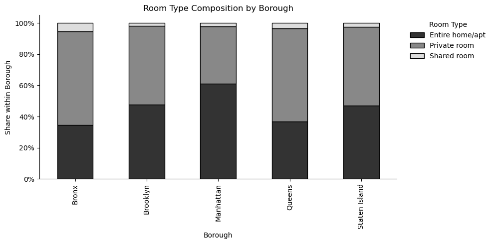

```python
#==============================================
# Figure 1: Room Type Distribution Comparison
#==============================================
counts = pd.crosstab(df["neighbourhood_group"], df["room_type"])
shares = counts.div(counts.sum(axis=1), axis=0)
colors = ["#333333","#888888","#DDDDDD"]

ax = shares.plot(
    kind="bar",
    stacked=True,
    figsize=(10, 5),
    color=colors,
    edgecolor="black")

ax.set_ylabel("Share within Borough")
ax.set_xlabel("Borough")
ax.set_title("Room Type Composition by Borough")
ax.yaxis.set_major_formatter(mtick.PercentFormatter(1.0))

ax.legend(
    title="Room Type",
    bbox_to_anchor=(1.02, 1),
    loc="upper left",
    frameon=False)

ax.spines['right'].set_visible(False)
ax.spines['top'].set_visible(False)

plt.tight_layout()
plt.show()
```

This figure shows the distribution of room types across boroughs. Manhattan has a higher share of entire-home listings, while the Bronx and Queens are dominated by private rooms. This suggests systematic differences in Airbnb supply structure, which may contribute to price variation.

### 1.4.2 Figure 2: Affordability Comparison through Price-to-income Ratio

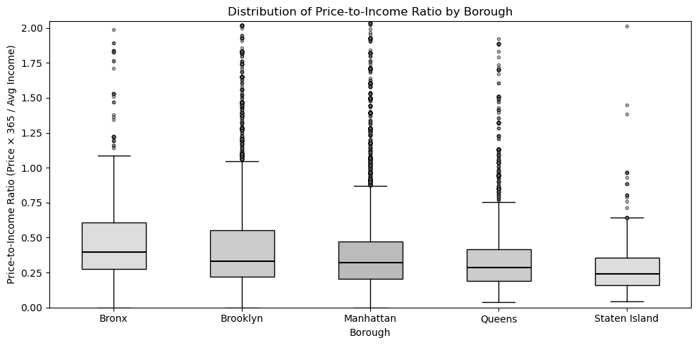

```python
# ============================================
# Figure 2: Price-to-income Ratio Comparison
# ============================================
borough_order = ["Bronx", "Brooklyn", "Manhattan", "Queens", "Staten Island"]
data = []
labels = []

for b in borough_order:
    sub = (
        df1.loc[df1["neighbourhood_group"] == b, "Price_to_Income Ratio"]
           .replace([np.inf, -np.inf], np.nan)
           .dropna())
    if len(sub) > 0:
        data.append(sub.to_numpy())
        labels.append(b)

fig, ax = plt.subplots(figsize=(10, 5))

bp = ax.boxplot(
    data,
    showfliers=True,
    patch_artist=True,
    medianprops=dict(color="black", linewidth=1.5),
    boxprops=dict(edgecolor="black"),
    whiskerprops=dict(color="black"),
    capprops=dict(color="black"),
    flierprops=dict(marker="o", markersize=3, markerfacecolor="gray", alpha=0.5))

fills = ["#DDDDDD", "#CCCCCC", "#BBBBBB", "#CCCCCC", "#DDDDDD"]
for patch, c in zip(bp["boxes"], fills):
    patch.set_facecolor(c)

ax.set_xticks(range(1, len(labels) + 1))
ax.set_xticklabels(labels)

ax.set_title("Distribution of Price-to-Income Ratio by Borough")
ax.set_xlabel("Borough")
ax.set_ylabel("Price-to-Income Ratio (Price × 365 / Avg Income)")

upper = np.nanpercentile(df1["Price_to_Income Ratio"], 99)
ax.set_ylim(0, upper)

plt.tight_layout()
plt.show()
```

This figure uses the price-to-income ratio to measure Airbnb affordability across boroughs. The boxplots show that the median price-to-income ratio is highest in the Bronx and lowest in Staten Island, with substantial variation across boroughs, indicating that Airbnb affordability differs significantly by location.

### 1.4.3 Figure 3: Relationship between Price & Availability

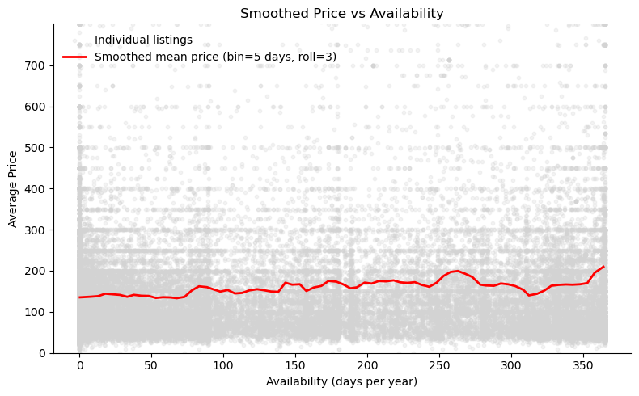

```python
# ==================================
# Figure 3: Price VS. Availability
# ==================================
dfp = df1[["availability_365", "price"]].copy()
dfp = dfp.replace([np.inf, -np.inf], np.nan).dropna()

fig, ax = plt.subplots(figsize=(8, 5))
ax.scatter(
    dfp["availability_365"],
    dfp["price"],
    color="lightgray",
    alpha=0.25,
    s=10,
    label="Individual listings")

bin_width = 5
bins = np.arange(0, 365 + bin_width, bin_width)
dfp["avail_bin"] = pd.cut(dfp["availability_365"], bins=bins, include_lowest=True)

binned = (
    dfp.groupby("avail_bin", observed=True)
       .agg(mean_avail=("availability_365", "mean"),
            mean_price=("price", "mean"),
            n=("price", "size"))
       .dropna()
       .sort_values("mean_avail"))
window = 3
binned["smooth_price"] = binned["mean_price"].rolling(window=window, center=True, min_periods=1).mean()

ax.plot(
    binned["mean_avail"],
    binned["smooth_price"],
    color="red",
    linewidth=2,
    label=f"Smoothed mean price (bin={bin_width} days, roll={window})")

ax.set_ylim(0, np.percentile(dfp["price"], 99))
ax.set_title("Smoothed Price vs Availability")
ax.set_xlabel("Availability (days per year)")
ax.set_ylabel("Average Price")
ax.legend(frameon=False)
ax.spines['right'].set_visible(False)
ax.spines['top'].set_visible(False)

plt.tight_layout()
plt.show()
```

This figure examines the relationship between Airbnb prices and availability. Availability is chosen because it reflects how often a listing is available for booking and serves as a proxy for supply conditions. The economic question is whether prices seen to vary systematically with availability. While individual prices are highly dispersed, the smoothed average line is relatively flat. This suggests that availability alone does not strongly explain Airbnb price differences at the aggregate level.

### 1.4.4 Figure 4: Population VS Listing Share

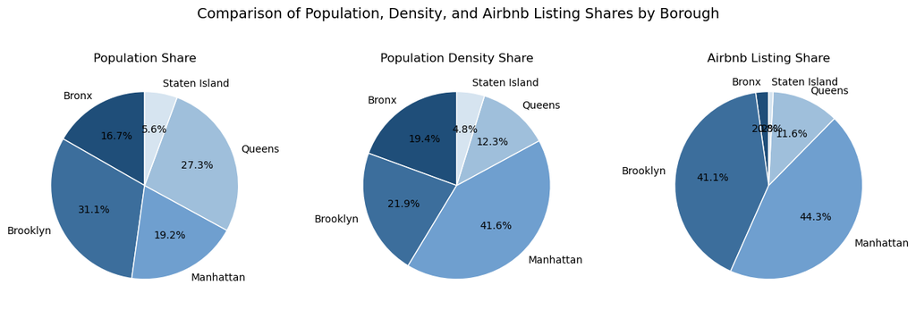

```python
# =======================================
# Figure 4: Population VS Listing Share
# =======================================
listing_count = (df1.groupby("neighbourhood_group")
                 .size()
                 .reset_index(name="listings"))

pop_density = (nbh_data_m[["neighbourhood_group", "Population", "Pop_Density"]].drop_duplicates())
dfp2 = (listing_count.merge(pop_density, on="neighbourhood_group", how="left"))

# Calculate Shares
dfp2["listing_share"] = dfp2["listings"] / dfp2["listings"].sum()
dfp2["population_share"] = dfp2["Population"] / dfp2["Population"].sum()
dfp2["density_share"] = dfp2["Pop_Density"] / dfp2["Pop_Density"].sum()
dfp2["neighbourhood_group"] = pd.Categorical(
    dfp2["neighbourhood_group"],
    categories=borough_order,
    ordered=True)
dfp2 = dfp2.sort_values("neighbourhood_group")

colors = ["#1F4E79","#3C6E9C","#6F9FCF","#9FBFDB","#D6E4F0"]
labels = dfp2["neighbourhood_group"]

fig, axes = plt.subplots(1, 3, figsize=(13, 4))

# Pie1: Population Share
axes[0].pie(
    dfp2["population_share"],
    labels=labels,
    autopct="%1.1f%%",
    startangle=90,
    colors=colors,
    wedgeprops=dict(edgecolor="white"))
axes[0].set_title("Population Share")

# Pie2: Population Density Share
axes[1].pie(
    dfp2["density_share"],
    labels=labels,
    autopct="%1.1f%%",
    startangle=90,
    colors=colors,
    wedgeprops=dict(edgecolor="white"))
axes[1].set_title("Population Density Share")

# Pie3: Airbnb Listing Share
axes[2].pie(
    dfp2["listing_share"],
    labels=labels,
    autopct="%1.1f%%",
    startangle=90,
    colors=colors,
    wedgeprops=dict(edgecolor="white"))
axes[2].set_title("Airbnb Listing Share")

fig.suptitle(
    "Comparison of Population, Density, and Airbnb Listing Shares by Borough",
    fontsize=14,
    y=1.05)

plt.tight_layout()
plt.show()
```

This figure compares borough-level shares of population, density, and Airbnb listings to examine whether supply aligns with local demographic patterns. The data reveal a disproportionate concentration of short-term rentals in Manhattan and Brooklyn, where listing shares far exceed population shares.

Integrating Figures 2 and 4 highlights a decoupling between listing density and affordability: this spatial concentration does not necessarily translate to lower prices relative to local income. In fact, some boroughs with fewer listings maintain higher price-to-income ratios. A potential explanation lies in neighborhood safety; higher crime rates may suppress visitor willingness to pay, thereby shaping pricing outcomes. We explore this spatial relationship between crime and pricing in the subsequent mapping section.

# 2. Project Two

## 2.1 The Message

#### Message

*Airbnb listings located in neighborhoods with stronger economic environments, reflected in higher income levels, tend to exhibit higher price levels.*

Note: In this study, the neighborhood economic environment refers broadly to local economic and social conditions, which influence local housing demand and supply. These conditions include income levels, economic productivity(proxied by GDP per capita), population density, and neighborhood safety (proxied by crime rates). Average income level serves as the primary observable indicator of local economic strength in the boxplot visualization presented below.

#### Description

The figure illustrates the distribution of Airbnb listing prices across the boroughs of New York City, and compares them with the average daily household income levels in each borough. The boxplots display the distribution of Airbnb listing prices, while the dashed red lines represent the average daily income level, calculated as annual household income divided by 365.

A positive association between local income levels and Airbnb prices can be observed. Boroughs with stronger economic conditions, such as Manhattan, tend to exhibit substantially higher Airbnb prices, whereas boroughs with lower income levels display lower price distributions. This pattern provides intuitive evidence that differences in neighborhood economic environments are associated with systematic variation in Airbnb price levels.

[figure not shown]

```python
# Data Measurement
borough_order = ["Bronx", "Brooklyn", "Manhattan", "Queens", "Staten Island"]
price_clean = df1["price"].replace([np.inf, -np.inf], np.nan).dropna()
upper = np.percentile(price_clean, 99)

data = []
mean_prices = []
daily_income = []

for b in borough_order:
    sub = df1.loc[df1["neighbourhood_group"] == b, "price"]
    sub = sub.replace([np.inf, -np.inf], np.nan).dropna()
    data.append(sub)
    mean_prices.append(sub.mean())
    income = (
        df1.loc[df1["neighbourhood_group"] == b, "Avg Income"]
        .replace([np.inf, -np.inf], np.nan)
        .dropna()
        .mean() / 365)
    daily_income.append(income)

# Create figure
fig, ax = plt.subplots(figsize=(10,5))

bp = ax.boxplot(
    data,
    showfliers=False,
    patch_artist=True,
    medianprops=dict(color="black", linewidth=1.5),
    boxprops=dict(edgecolor="black"),
    whiskerprops=dict(color="black"),
    capprops=dict(color="black"))

colors = ["#DDDDDD","#CCCCCC","#BBBBBB","#CCCCCC","#DDDDDD"]

for patch, c in zip(bp["boxes"], colors):
    patch.set_facecolor(c)

x = np.arange(1, len(borough_order)+1)

ax.scatter(x, mean_prices, color="darkred", s=80, zorder=3, label="Average Airbnb Price")

# Daily income dashed lines
for i, inc in enumerate(daily_income):
    ax.hlines(
        inc,
        i+1-0.35,
        i+1+0.35,
        colors="red",
        linestyles="dashed",
        linewidth=2,
        label="Average Daily Income" if i == 0 else "")

# Plot Labels
ax.set_xticks(x)
ax.set_xticklabels(borough_order)

ax.set_ylabel("Airbnb Price per Night")
ax.set_xlabel("Borough")
ax.set_title("Airbnb Price Distribution Relative to Local Income Levels")

# Limit extreme outliers
ax.set_ylim(0, upper)
ax.legend(frameon=False)

ax.spines['right'].set_visible(False)
ax.spines['top'].set_visible(False)

plt.tight_layout()
plt.show()
```

## 2.2 Maps and Interpretations

To better understand the spatial distribution of Airbnb prices and neighborhood conditions across NYC, this section presents a series of maps that visualizes key variables related to the neighborhood economic environment, providing intuitive insights into how neighborhood characteristics vary across the city.

```python
from shapely.geometry import Point

# Create GeoDataframe
df1["Coordinates"] = list(zip(df1.longitude, df1.latitude))
df1["Coordinates"] = df1["Coordinates"].apply(Point)

gdf = gpd.GeoDataFrame(df1, geometry="Coordinates")
gdf = gdf.set_crs(epsg=4326)
```

```python
# Create Map
zcta_df = gpd.read_file("https://www2.census.gov/geo/tiger/GENZ2018/shp/cb_2018_us_zcta510_500k.zip")
tract_df = gpd.read_file("https://www2.census.gov/geo/tiger/GENZ2018/shp/cb_2018_36_tract_500k.zip")

borough_map = {
    "005": "Bronx",
    "047": "Brooklyn",
    "061": "Manhattan",
    "081": "Queens",
    "085": "Staten Island"}

tract_df["COUNTYFP"] = tract_df["COUNTYFP"].astype(str)
tract_df["borough"] = tract_df["COUNTYFP"].map(borough_map)

nyc_tracts = tract_df[tract_df["borough"].notna()].copy()
borough_df = nyc_tracts.dissolve(by="borough").reset_index()
target_crs = "EPSG:2263"

gdf = gdf.to_crs(target_crs)
zcta_df = zcta_df.to_crs(target_crs)
borough_df = borough_df.to_crs(target_crs)

nyc_union = borough_df.union_all()
nyc_zcta = zcta_df[zcta_df.intersects(nyc_union)].copy()
gdf_zip = gpd.sjoin(gdf, nyc_zcta, how="left", predicate="within")
```

### 2.2.1 Map1: Price of Airbnb Listing (Outcome Variable)

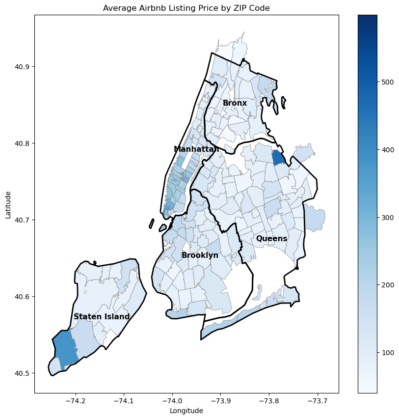

```python
map1_plot = nyc_zcta_price.to_crs(epsg=4326)
borough_plot = borough_df.to_crs(epsg=4326)

fig, ax = plt.subplots(1,1,figsize=(10,10))

map1_plot.plot(
    column="price",
    cmap="Blues",
    linewidth=0.5,
    edgecolor="gray",
    legend=True,
    ax=ax)

borough_plot.boundary.plot(ax=ax, color="black", linewidth=2)

for _, row in borough_plot.iterrows():
    p = row.geometry.representative_point()
    ax.text(
        p.x,
        p.y,
        row["borough"],
        ha="center",
        va="center",
        fontsize=11,
        fontweight="bold",
        color="black")

ax.set_title("Average Airbnb Listing Price by ZIP Code")
ax.set_xlabel("Longitude")
ax.set_ylabel("Latitude")
ax.set_aspect("auto")

plt.show()
```

This map shows the spatial distribution of average Airbnb prices. Prices are highly concentrated in Manhattan, with some moderately high values in parts of State Island and Queens. This pattern is consistent with the stronger economic environment and tourism activity in Manhattan, which likely increases visitors' willingness to pay for short-term accommodation. A few isolated high-price areas may reflect local outliers or luxury listings.

### 2.2.2 Map 2: Crime Rate (Important Independent Variable)

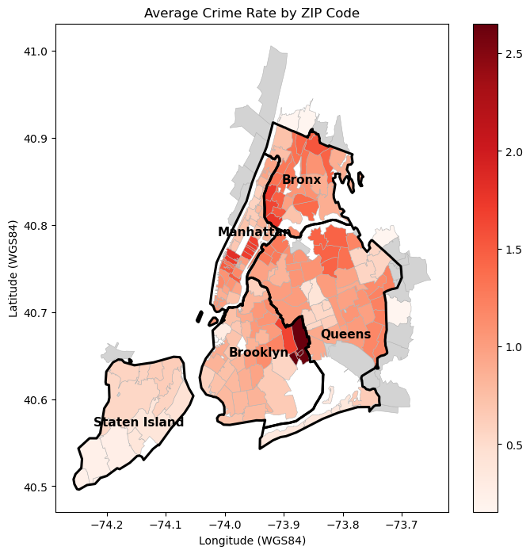

```python
ma2p_plot = nyc_zcta_crime.to_crs(epsg=4326)

fig, ax = plt.subplots(figsize=(8, 8))

map2_plot.plot(
    ax=ax,
    column="crime_rate",
    cmap="Reds",
    edgecolor="0.7",
    linewidth=0.4,
    legend=True,
    missing_kwds={
        "color": "lightgrey",
        "label": "No data"})

borough_plot.plot(ax=ax, facecolor="none", edgecolor="black", linewidth=2.2,)

for _, row in borough_plot.iterrows():
    p = row.geometry.representative_point()
    ax.text(
        p.x, p.y,
        row["borough"],
        ha="center",
        va="center",
        fontsize=11,
        fontweight="bold",
        color="black")

ax.set_title("Average Crime Rate by ZIP Code")
ax.set_xlabel("Longitude (WGS84)")
ax.set_ylabel("Latitude (WGS84)")
ax.set_aspect("auto")

plt.show()
```

### 2.2.3 Map 3: Price to Income Ratio

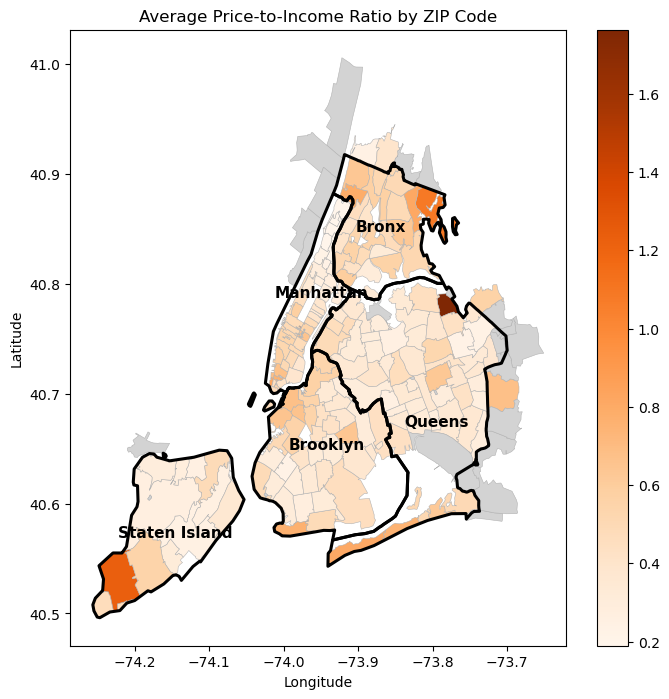

```python
map3_plot = nyc_zcta_map.to_crs(epsg=4326)

fig, ax = plt.subplots(figsize=(8, 8))

map3_plot.plot(
    ax=ax,
    column="Price_to_Income Ratio",
    cmap="Oranges",
    edgecolor="0.7",
    linewidth=0.4,
    legend=True,
    missing_kwds={
        "color": "lightgrey",
        "label": "No data"})

borough_plot.plot(ax=ax, facecolor="none", edgecolor="black", linewidth=2.2,)

for _, row in borough_plot.iterrows():
    p = row.geometry.representative_point()
    ax.text(
        p.x, p.y,
        row["borough"],
        ha="center",
        va="center",
        fontsize=11,
        fontweight="bold",
        color="black")

ax.set_title("Average Price-to-Income Ratio by ZIP Code")
ax.set_xlabel("Longitude")
ax.set_ylabel("Latitude")
ax.set_aspect("auto")

plt.show()
```

This map presents the spatial distribution of the price-to-income ratio, measuring Airbnb affordability. Higher ratios are observed in parts of the Bronx, where lower income leads to relatively higher price burdens. In contrast, Manhattan shows more moderate ratios despite high prices, due to higher income levels. This highlights that affordability patterns differ from absolute price levels.

### 2.2.4 Map 4: Airbnb Listing Density

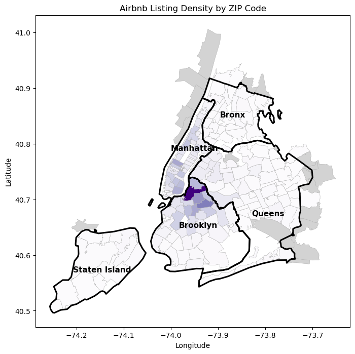

```python
zip_listings = (
    gdf_zip
    .groupby("ZCTA5CE10")
    .size()
    .reset_index(name="listing_count"))

nyc_zcta_listings = nyc_zcta.merge(zip_listings, on="ZCTA5CE10", how="left")

map4_plot = nyc_zcta_listings.to_crs(epsg=4326)

fig, ax = plt.subplots(figsize=(8, 8))

map4_plot.plot(
    ax=ax,
    column="listing_count",
    cmap="Purples",
    edgecolor="0.7",
    linewidth=0.4,
    legend=False,
    missing_kwds={
        "color": "lightgrey",
        "label": "No data"})

borough_plot.plot(ax=ax, facecolor="none", edgecolor="black", linewidth=2.2)

for _, row in borough_plot.iterrows():
    p = row.geometry.representative_point()
    ax.text(
        p.x, p.y,
        row["borough"],
        ha="center",
        va="center",
        fontsize=11,
        fontweight="bold",
        color="black")

ax.set_title("Airbnb Listing Density by ZIP Code")
ax.set_xlabel("Longitude")
ax.set_ylabel("Latitude")
ax.set_aspect("auto")

plt.show()
```

This map illustrates Airbnb listing density. Listings are highly concentrated in Manhattan and Brooklyn, reflecting strong tourism demand and central location advantages. In contrast, the Bronx and Staten Island show much lower levels of Airbnb activity, indicating weaker market presence.

### 2.2.5 Map 5: Median Income

```python
income_df = pd.read_csv("nyc_zip_income.csv")
income_df["ZCTA5CE10"] = income_df["ZIP Code"].astype(str)
nyc_zcta_income = nyc_zcta.merge(income_df,on="ZCTA5CE10",how="left")

df1 = df1.merge(gdf_zip[["id", "ZCTA5CE10"]],on="id",how="left")
df1 = df1.merge(income_df[["ZCTA5CE10", "Median Income"]],on="ZCTA5CE10",how="left")
```

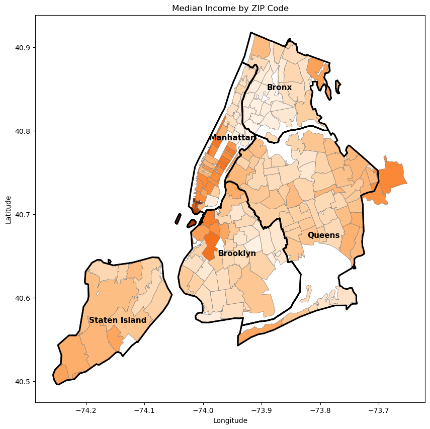

```python
map5_plot = nyc_zcta_income.to_crs(epsg=4326)
borough_plot = borough_df.to_crs(epsg=4326)

fig, ax = plt.subplots(1, 1, figsize=(10, 10))

map5_plot.plot(
    column="Median Income",
    cmap="Oranges",
    linewidth=0.5,
    edgecolor="gray",
    legend=False,
    ax=ax
)

borough_plot.boundary.plot(ax=ax, color="black", linewidth=2)

borough_plot.plot(ax=ax, facecolor="none", edgecolor="black", linewidth=2.2,)

for _, row in borough_plot.iterrows():
    p = row.geometry.representative_point()
    ax.text(
        p.x, p.y,
        row["borough"],
        ha="center",
        va="center",
        fontsize=11,
        fontweight="bold",
        color="black")

ax.set_title("Median Income by ZIP Code")
ax.set_xlabel("Longitude")
ax.set_ylabel("Latitude")
ax.set_aspect("auto")

plt.show()
```

This map shows the spatial distribution of median income. Higher-income areas are mainly concentrated in Manhattan, while other boroughs display lower income levels. This pattern aligns with the price distribution, suggesting that stronger economic conditions are associated with higher Airbnb prices.

## 2.3 Regressions

### 2.3.3 Regression Table

The regression models progressively add groups of variables to examine how estimated relationships change with additional controls. This approach helps isolate the effects of neighborhood conditions, listing characteristics, and location.

```python
import statsmodels.api as sm
```

```python
# dependent variables (outcome)
y = df1["price"]
y2 = df1["log_price"]

# create dummy variables
room_dummies = pd.get_dummies(df1["room_type"], drop_first=True).astype(float)
borough_dummies = pd.get_dummies(df1["neighbourhood_group"], drop_first=True).astype(float)
```

```python
# Benchmark: price on crime_rate
Xb = sm.add_constant(df1[["crime_rate"]])
bench = sm.OLS(y, Xb, missing="drop").fit()

# Model 1: crime + income
X1 = sm.add_constant(df1[["crime_rate", "avg_income_10k"]])
reg1 = sm.OLS(y, X1, missing="drop").fit()

# Model 2: + GDP
X2 = sm.add_constant(df1[["crime_rate", "avg_income_10k", "availability_365", "minimum_nights", "number_of_reviews"]])
reg2 = sm.OLS(y, X2, missing="drop").fit()

# Model 3: + room type dummies
X3 = pd.concat([df1[["crime_rate", "avg_income_10k", "availability_365", "minimum_nights", "number_of_reviews"]], room_dummies], axis=1)
X3 = sm.add_constant(X3)
reg3 = sm.OLS(y, X3, missing="drop").fit()

# Model 4: + borough dummies
X4 = pd.concat([df1[["crime_rate", "avg_income_10k", "availability_365", "minimum_nights", "number_of_reviews"]], room_dummies, borough_dummies], axis=1)
X4 = sm.add_constant(X4)
reg4 = sm.OLS(y, X4, missing="drop").fit()

# Stargazer Table 1
stargazer1 = Stargazer([bench, reg1, reg2, reg3, reg4])
stargazer1.title("Table 1: Neighborhood, Location and Housing Type Effects on Airbnb Prices")
stargazer1.custom_columns(["Benchmark","M1","M2","M3","M4"], [1,1,1,1,1])
display(HTML(stargazer1.render_html()))
```

Table 1: Neighborhood, Location and Housing Type Effects on Airbnb Prices

|  | *Dependent variable: price* |  |  |  |  |
| --- | --- | --- | --- | --- | --- |
|  | Benchmark | M1 | M2 | M3 | M4 |
|  | (1) | (2) | (3) | (4) | (5) |
| Brooklyn |  |  |  |  | -1.681 |
|  |  |  |  |  | (5.138) |
| Manhattan |  |  |  |  | -14.523*** |
|  |  |  |  |  | (3.516) |
| Private room |  |  |  | -111.409*** | -110.777*** |
|  |  |  |  | (2.133) | (2.136) |
| Queens |  |  |  |  | -19.384*** |
|  |  |  |  |  | (5.729) |
| Shared room |  |  |  | -145.318*** | -144.326*** |
|  |  |  |  | (6.895) | (6.897) |
| Staten Island |  |  |  |  | -36.611*** |
|  |  |  |  |  | (11.182) |
| availability_365 |  |  | 0.165*** | 0.174*** | 0.180*** |
|  |  |  | (0.008) | (0.008) | (0.008) |
| avg_income_10k |  | 10.649*** | 10.580*** | 8.149*** | 9.361*** |
|  |  | (0.294) | (0.293) | (0.288) | (0.656) |
| const | 127.118*** | 1.287 | -5.390 | 81.830*** | 74.547*** |
|  | (3.030) | (4.580) | (4.661) | (4.817) | (11.307) |
| crime_rate | 25.603*** | 13.200*** | 7.858*** | 7.038*** | 7.373*** |
|  | (2.829) | (2.812) | (2.809) | (2.731) | (2.787) |
| minimum_nights |  |  | 0.164*** | -0.020 | -0.028 |
|  |  |  | (0.053) | (0.052) | (0.052) |
| number_of_reviews |  |  | -0.296*** | -0.307*** | -0.306*** |
|  |  |  | (0.024) | (0.024) | (0.024) |
| Observations | 48895 | 48895 | 48895 | 48895 | 48895 |
| R<sup>2</sup> | 0.002 | 0.028 | 0.038 | 0.092 | 0.093 |
| Adjusted R<sup>2</sup> | 0.002 | 0.028 | 0.038 | 0.092 | 0.092 |
| Residual Std. Error | 239.956 (df=48893) | 236.795 (df=48892) | 235.566 (df=48889) | 228.854 (df=48887) | 228.784 (df=48884) |
| F Statistic | 81.925*** (df=1; 48893) | 699.557*** (df=2; 48892) | 385.646*** (df=5; 48889) | 707.784*** (df=7; 48887) | 499.050*** (df=10; 48884) |
| Note: | *p<0.1; **p<0.05; ***p<0.01 |  |  |  |  |

```python
# Model 5: log(price) on crime + income
X5 = sm.add_constant(df1[["crime_rate", "avg_income_10k"]])
reg5 = sm.OLS(y2, X5, missing="drop").fit()

# Model 6: + listing characteristics + reviews
X6 = sm.add_constant(df1[["crime_rate", "avg_income_10k", "availability_365", "minimum_nights", "number_of_reviews"]])
reg6 = sm.OLS(y2, X6, missing="drop").fit()

# Model 7: + room type
X7 = pd.concat([df1[["crime_rate","avg_income_10k","availability_365","minimum_nights","number_of_reviews"]], room_dummies], axis=1)
reg7 = sm.OLS(y2, X7, missing="drop").fit()

# Model 8: + borough + room type
X8 = pd.concat([df1[["crime_rate","avg_income_10k","availability_365","minimum_nights","number_of_reviews"]], room_dummies, borough_dummies], axis=1)
X8 = sm.add_constant(X8)
reg8 = sm.OLS(y2, X8, missing="drop").fit()

# Stargazer Table 2
stargazer2 = Stargazer([reg5, reg6, reg7, reg8])
stargazer2.title("Table 2: Airbnb Market Characteristics and Log Prices")
stargazer2.custom_columns(["M5","M6","M7","M8"], [1,1,1,1])
display(HTML(stargazer2.render_html()))
```

Table 2: Airbnb Market Characteristics and Log Prices

|  | *Dependent variable: log_price* |  |  |  |
| --- | --- | --- | --- | --- |
|  | M5 | M6 | M7 | M8 |
|  | (1) | (2) | (3) | (4) |
| Brooklyn |  |  |  | -0.389*** |
|  |  |  |  | (0.011) |
| Manhattan |  |  |  | -1.245*** |
|  |  |  |  | (0.008) |
| Private room |  |  | -0.117*** | -0.776*** |
|  |  |  | (0.009) | (0.005) |
| Queens |  |  |  | -0.479*** |
|  |  |  |  | (0.013) |
| Shared room |  |  | -0.707*** | -1.170*** |
|  |  |  | (0.032) | (0.015) |
| Staten Island |  |  |  | -0.855*** |
|  |  |  |  | (0.025) |
| availability_365 |  | 0.001*** | 0.002*** | 0.001*** |
|  |  | (0.000) | (0.000) | (0.000) |
| avg_income_10k | 0.066*** | 0.066*** | 0.246*** | 0.165*** |
|  | (0.001) | (0.001) | (0.001) | (0.001) |
| const | 3.824*** | 3.791*** |  | 3.664*** |
|  | (0.013) | (0.013) |  | (0.025) |
| crime_rate | 0.055*** | 0.037*** | 1.184*** | 0.036*** |
|  | (0.008) | (0.008) | (0.011) | (0.006) |
| minimum_nights |  | -0.000** | -0.000 | -0.002*** |
|  |  | (0.000) | (0.000) | (0.000) |
| number_of_reviews |  | -0.001*** | 0.002*** | -0.001*** |
|  |  | (0.000) | (0.000) | (0.000) |
| Observations | 48895 | 48895 | 48895 | 48895 |
| R<sup>2</sup> | 0.125 | 0.138 | 0.950 | 0.469 |
| Adjusted R<sup>2</sup> | 0.125 | 0.138 | 0.950 | 0.469 |
| Residual Std. Error | 0.650 (df=48892) | 0.646 (df=48889) | 1.074 (df=48888) | 0.507 (df=48884) |
| F Statistic | 3505.965*** (df=2; 48892) | 1563.782*** (df=5; 48889) | 131693.224*** (df=7; 48888) | 4322.158*** (df=10; 48884) |
| Note: | *p<0.1; **p<0.05; ***p<0.01 |  |  |  |

### 2.3.4 Preferred Model Specification

The preferred model is $Model$ $8$, and its regression specification can be written as:

\begin{equation} \log(Price_i) = \beta_0 + \beta_1 CrimeRate_i + \beta_2 Avg_Income_i \end{equation} \begin{equation} + \beta_3 Availability_i + \beta_4 MinimumNights_i + \beta_5 Reviews_i \end{equation} \begin{equation} + \beta_6 PrivateRoom_i + \beta_7 SharedRoom_i \end{equation} \begin{equation} + \beta_8 Brooklyn_i + \beta_9 Manhattan_i + \beta_{10} Queens_i + \beta_{11} StatenIsland_i + \varepsilon_i \end{equation}

The model uses the logarithm of price as the dependent variable and includes neighborhood variables, listing characteristics, room type, and borough indicators. It is chosen because it provides a comprehensive specification while maintaining a stable and interpretable structure.

### 2.3.5 Regression Results

The regression results show several clear patterns. First, average income has a positive and statistically significant effect, indicating that listings in higher-income neighborhoods tend to have higher prices. Second, housing characteristics are important. Compared with entire homes, both private and shared rooms are significantly cheaper, reflecting differences in space and privacy. Finally, listing characteristics and location also contribute to price variation. Variables such as availability, minimum nights, and reviews are associated with pricing outcomes, while borough indicators capture remaining spatial differences.

# 3. Final Project

## 3.1 Potential Data to Scrape

To further enhance the analysis, we need to incorporate new datasets that capture local tourism attractiveness. Specifically, I plan to scrape data from a website that provides a list of popular attractions in NYC. This dataset is not available to download as a structured format such as CSV; instead, the information is embedded within the website’s HTML structure across multiple entries. As a result, manual data collection is not feasible due to the large number of observations and the risk of errors, making web scraping necessary to systematically extract and organize the data.

I also explored alternative business platforms to collect information on popular restaurants, tourist-friendly locations, and hotels, which may serve as substitutes or competitors to Airbnb. However, these platforms employ strong anti-scraping mechanisms, making it difficult to extract data reliably. Furthermore, their official APIs are often paid or provide data at a broader scale that is not restricted to NYC, which does not align well with the scope of this study. Therefore, these sources were not suitable, and I focus instead on a curated attraction website that allows for feasible and targeted data collection.

## 3.2 Potential Challenges

There are several challenges associated with scraping this data. First, the structure of the website may be complex or subject to change over time, which can affect the stability of the scraping code. Some elements may also be dynamically loaded, increasing the difficulty of extraction. Second, the scraped data may introduce measurement errors, particularly in the popularity indicator.

Unlike platforms such as Yelp or Booking.com, the selected data source does not require repeated scraping over time, and a one-time data collection is sufficient for this project. However, it is important to note that the selected data source contains a relatively limited number of observations. As a result, it may not fully capture the complete distribution of tourism activity across NYC. In particular, cultural and tourism-related activities may be often highly concentrated in specific areas, which may lead to an overrepresentation of certain regions and an underrepresentation of others. This limitation should be considered when interpreting the results, as the constructed tourism intensity variable may not perfectly reflect the true spatial distribution of tourist demand.

Despite these challenges, it is still feasible to scrape a substantial portion of the data and use it for visualization and regression analysis, providing meaningful insights into the relationship between tourism attractiveness and Airbnb prices.

## 3.3 Scraping Data from a Website

```python
import json
import requests
from pathlib import Path
from bs4 import BeautifulSoup
```

```python
web_url = "https://d15ldvyocwqu5y.cloudfront.net/jsonws/clm-20250318122912/new-york-city/attractions/all"
response = requests.get(web_url)
data = response.json()
```

```python
# Create an empty DataFrame to store the scraped data
attractions_df = pd.DataFrame(columns=['attraction_name', 'latitude', 'longitude', 'rating', 'popularity'])
ix = 0

for item in data['lstSites']:
    # Extract name
    attraction_name = item.get('name')
    # Extract coordinates
    latitude = item.get('longitude')
    longitude = item.get('latitude')
    # Extract rating and popularity
    rating = item.get('calculatedRating')
    popularity = item.get('userItinerariesCount')
    # Store
    attractions_df.loc[ix] = [attraction_name, latitude, longitude, rating, popularity]
    ix += 1

# Check top 5
attractions_df.head()
```

|  | attraction_name | latitude | longitude | rating | popularity |
| --- | --- | --- | --- | --- | --- |
| 0 | Times Square | 40.758897 | -73.985133 | 5.0 | 169292 |
| 1 | Empire State Building | 40.748525 | -73.985603 | 5.0 | 165207 |
| 2 | Brooklyn Bridge | 40.708000 | -73.999173 | 5.0 | 156545 |
| 3 | Grand Central Terminal | 40.752998 | -73.977056 | 5.0 | 154173 |
| 4 | Central Park | 40.771133 | -73.974187 | 5.0 | 151509 |

## 3.4 Visualizaing the Scraped Dataset

### 3.4.1 Attraction Density Map

```python
attraction_gdf = gpd.GeoDataFrame(attractions_df,geometry=gpd.points_from_xy(
    attractions_df["longitude"],attractions_df["latitude"]),crs="EPSG:4326")

attraction_zip = gpd.sjoin(attraction_gdf,nyc_zcta,how="left",predicate="within")

attraction_zip_density = (
    attraction_zip.groupby("ZCTA5CE10")
    .size()
    .reset_index(name="attraction_count"))
```

```python
nyc_zcta["ZCTA5CE10"] = nyc_zcta["ZCTA5CE10"].astype(str)
attraction_zip_density["ZCTA5CE10"] = attraction_zip_density["ZCTA5CE10"].astype(str)
nyc_zcta_attraction = nyc_zcta.merge(attraction_zip_density,on="ZCTA5CE10",how="left")
nyc_zcta_attraction["attraction_count"] = (nyc_zcta_attraction["attraction_count"].fillna(0))
```

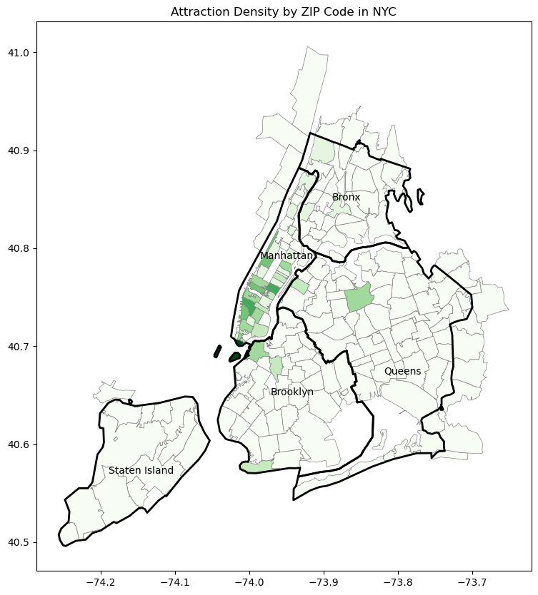

```python
map_plot = nyc_zcta_attraction.to_crs(epsg=4326)
borough_plot = borough_df.to_crs(epsg=4326)

fig, ax = plt.subplots(figsize=(10, 10))

map_plot.plot(
    column="attraction_count",
    cmap="Greens",
    linewidth=0.5,
    edgecolor="gray",
    legend=False,
    ax=ax)

borough_plot.boundary.plot(ax=ax, color="black", linewidth=2)
borough_plot.plot(ax=ax, facecolor="none", edgecolor="black")

for _, row in borough_plot.iterrows():
    p = row.geometry.representative_point()
    ax.text(p.x, p.y, row["borough"], ha="center", va="center")

ax.set_title("Attraction Density by ZIP Code in NYC")
plt.show()
```

This map illustrates the spatial distribution of attraction density across New York City at the ZIP code level. The variable measures the number of attractions within each ZIP code, capturing the local concentration of tourism-related activities.

The map shows a strong spatial concentration of attractions in Manhattan, where multiple ZIP codes exhibit high density levels. In contrast, most areas in Brooklyn, Queens, and Staten Island display relatively low values, with only a few localized clusters. This pattern suggests that tourism activity is highly centralized rather than evenly distributed across the city.

It is important to note that this pattern should be interpreted with caution, as the dataset is constructed from a relatively small sample of just over 100 well-known attractions. As a result, the data may overrepresent major tourist landmarks while underrepresenting smaller or less popular sites, potentially exaggerating the degree of spatial concentration observed in the map.

Nevertheless, the observed spatial pattern remains consistent with the main message. Areas with higher attraction density, particularly in central locations such as Manhattan, also tend to coincide with regions that exhibit higher income levels in earlier results. This spatial overlap suggests that attractions are more concentrated in economically stronger neighborhoods, reinforcing the link between local economic conditions and Airbnb price variation.

### 3.4.2 Average Attraction Popularity by Borough

```python
# Create GeoDataFrame for attractions
attraction_gdf = gpd.GeoDataFrame(
    attractions_df,
    geometry=gpd.points_from_xy(
        attractions_df["longitude"],
        attractions_df["latitude"]
    ),crs="EPSG:4326")
attraction_gdf = attraction_gdf.to_crs(borough_df.crs)

attraction_borough_gdf = gpd.sjoin(
    attraction_gdf,
    borough_df,
    how="left",
    predicate="within")

borough_stats = (
    attraction_borough_gdf.groupby("borough")
    .agg(
        avg_popularity=("popularity", "mean"),
        avg_rating=("rating", "mean"),
        attraction_count=("popularity", "size"))
    .reset_index())
```

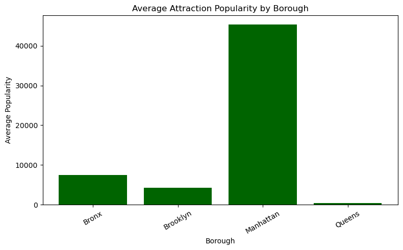

```python
fig, ax = plt.subplots(figsize=(8, 5))

ax.bar(
    borough_stats["borough"],
    borough_stats["avg_popularity"],
    color="darkgreen")

ax.set_title("Average Attraction Popularity by Borough")
ax.set_xlabel("Borough")
ax.set_ylabel("Average Popularity")

plt.xticks(rotation=30)
plt.tight_layout()
plt.show()
```

This bar plot shows the average popularity of attractions across boroughs in New York City. Manhattan exhibits the highest popularity, while other boroughs show lower levels, indicating differences in tourism attractiveness. This pattern is consistent with the spatial analysis, where central areas have higher attraction density. Together, these results suggest that tourism activity is both more concentrated and more prominent in central locations, which may help explain higher Airbnb prices in these areas.

## 3.5 Regression Tree

### 3.5.1 Object Function

The regression tree aims to partition the data into a set of regions such that the variation of the dependent variable within each region is minimized. In this project, the dependent variable is the logarithm of Airbnb prices, denoted as $log(price_𝑖)$. At each step, the model considers all possible listing features and possible split points, then selects the one that leads to the smallest MSE.

Formally, the regression tree solves the following objective:

\begin{equation} \min_{j,s} \left[ \sum_{i \in R_1(j,s)} (\log(\text{price}_i) - \hat{y}_{R_1})^2 + \sum_{i \in R_2(j,s)} (\log(\text{price}_i) - \hat{y}_{R_2})^2 \right] \end{equation}

where $R_1$ and $R_2$ are the two resulting regions, and $\hat{y_R}$ is the average log price within each region. This process continues until a stopping rule is reached, and each terminal node predicts the average log price of observations in that group.

### 3.5.2 Parameter Regularization

In regression trees, we prefer to use parameters to control model complexity and prevent overfitting.The main parameter is the maximum depth of the tree $(max$_$depth = 3)$, which limits how many times the tree can split. A smaller depth makes the model simpler, while a larger depth allows the model to capture more detailed patterns. If the tree is too deep, it may overfit the data and capture noise instead of real relationships. If the tree is too shallow, it may miss important patterns in Airbnb prices. By setting max_depth = 3, the model keeps a balance between being too simple and too complex, so it can capture key factors like income and room type without overfitting.

### 3.5.3 Regression Tree 1 (Preferred Variables)

```python
df1['ZIP Code'] = df1['ZCTA5CE10']
X = df1[['neighbourhood_group','room_type','minimum_nights', 'number_of_reviews',
       'availability_365','crime_rate','gdp_10k','density_1k', 'Median Income']].copy()
X = pd.get_dummies(X, drop_first=True)
log_y = df1["log_price"]
```

```python
import seaborn as sns
from sklearn import (tree, linear_model, metrics, pipeline, model_selection)
```

```python
sqft_tree = tree.DecisionTreeRegressor(max_depth=3).fit(X,y2)
y_pred_tree = sqft_tree.predict(X)

print('Mean Squared Error:', metrics.mean_squared_error(log_y,y_pred_tree))
```

```
Mean Squared Error: 0.2567866767005529
```

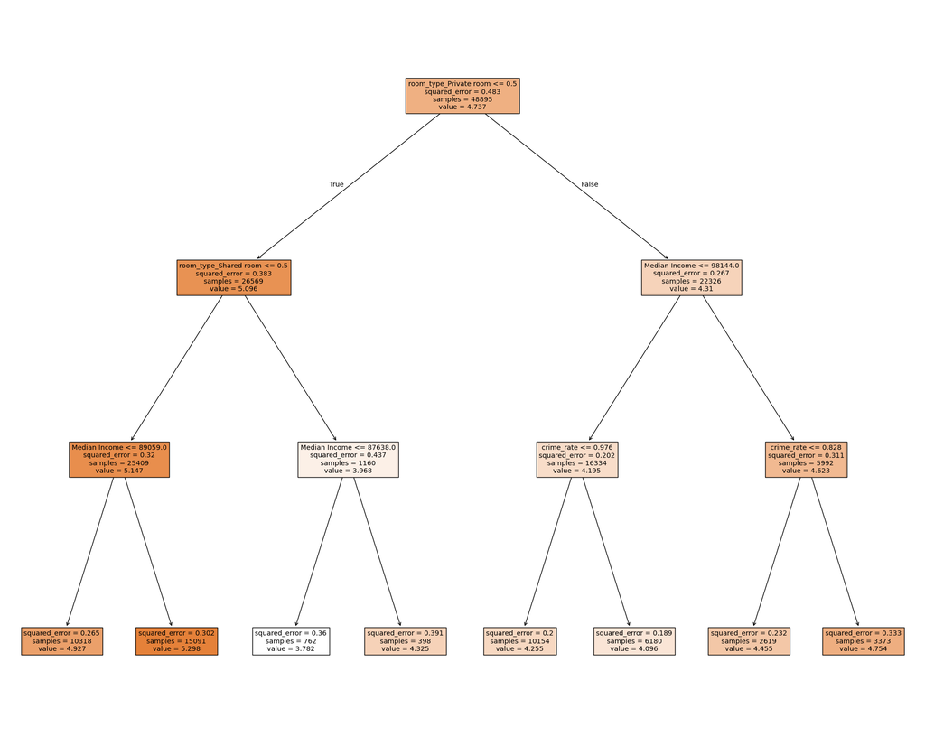

```python
sqrf_fig = plt.figure(figsize = (25,20))
sqrf_fig = tree.plot_tree(sqft_tree, feature_names=X.columns, filled=True)
```

### 3.5.4 Regression Tree 2 (All Variables)

```python
X_all = df1[['neighbourhood_group','room_type', 'minimum_nights', 'latitude', 'longitude','number_of_reviews',
             'calculated_host_listings_count','availability_365','crime_rate','gdp_10k','density_1k','Median Income']].copy()
X_all = pd.get_dummies(X_all, drop_first=True)
```

```python
sqft_tree2 = tree.DecisionTreeRegressor(max_depth=3).fit(X_all,log_y)
y_pred_tree2 = sqft_tree2.predict(X_all)

print('Mean Squared Error:', metrics.mean_squared_error(log_y,y_pred_tree2))
```

```
Mean Squared Error: 0.25656185579837193
```

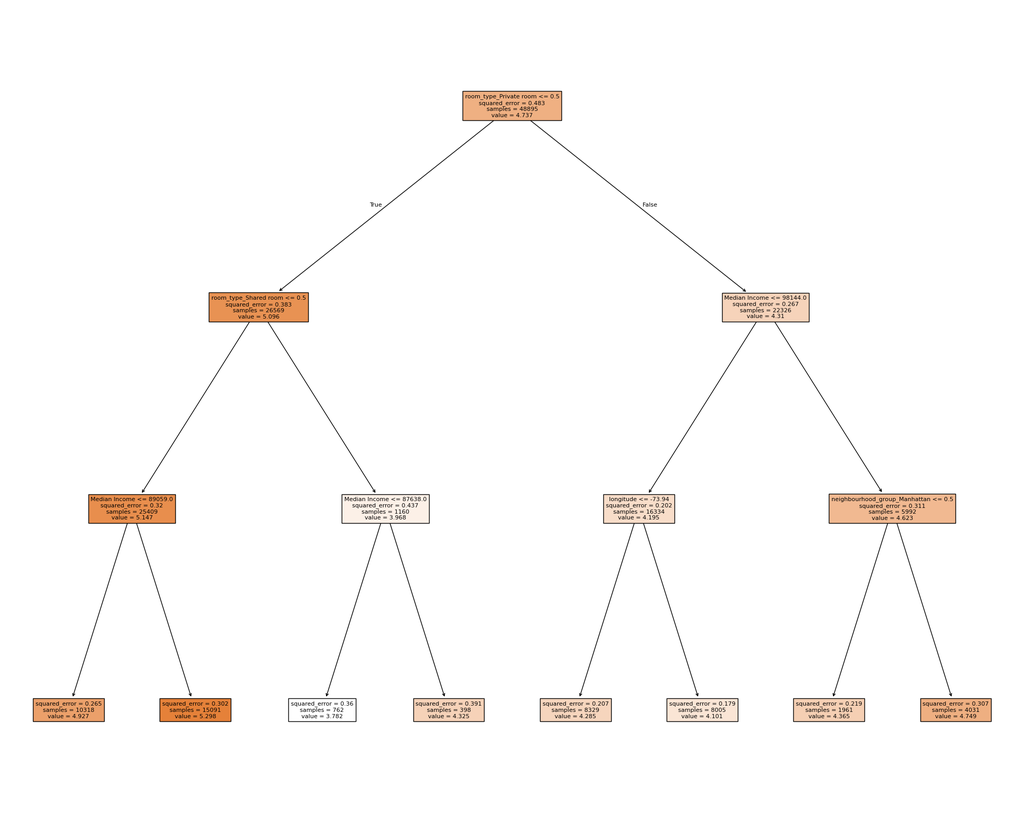

```python
sqrf_fig2 = plt.figure(figsize = (25,20))
sqrf_fig2 = tree.plot_tree(sqft_tree2, feature_names=X_all.columns, filled=True)
```

### 3.5.5 Results of Regression Trees

We first estimate a regression tree using variables from the preferred regression model, including room type, income, crime rate, and listing characteristics. The first split is on room type, indicating that it is the most important determinant of Airbnb prices, with entire homes having higher prices. The next key variable is income, showing that higher-income neighborhoods are associated with higher predicted prices. Even within the same room type, further splits on income suggest that neighborhood economic conditions continue to matter.

We then estimate a second tree using all available variables. The overall structure remains similar, confirming the importance of room type and income. However, the model begins to split on geographic coordinates. These splits should be interpreted with caution, as longitude and latitude do not represent meaningful economic distances and may reflect mechanical partitioning rather than true economic relationships. In contrast, categorical location variables are more economically meaningful. This comparison suggests that adding many variables does not substantially change the main results but may reduce interpretability.

The mean squared error (MSE) is approximately 0.256, indicating a reasonable level of prediction accuracy. The similarity between the two trees implies that key variables, such as room type and income, already capture most of the variation in Airbnb prices.

Overall, the regression tree provides a clear economic interpretation of pricing. Room type captures differences in housing quality and privacy, while income reflects local demand conditions. Crime rate and location variables further refine price differences. These results suggest that Airbnb prices are jointly determined by housing characteristics and neighborhood economic conditions.

## 3.6 Random Forest

```python
from sklearn.ensemble import BaggingClassifier, RandomForestClassifier, BaggingRegressor, RandomForestRegressor, GradientBoostingRegressor
from sklearn.metrics import mean_squared_error,confusion_matrix, classification_report
```

```
0.04899302403992999
```

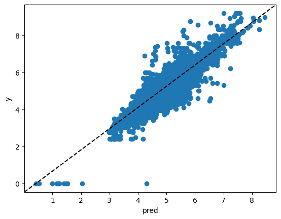

```python
regr_bagg = RandomForestRegressor(max_features= 5, random_state=1)
regr_bagg.fit(X, log_y)
pred = regr_bagg.predict(X)

plt.scatter(pred, log_y, label='log price')
plt.plot([0, 1], [0, 1], '--k', transform=plt.gca().transAxes)
plt.xlabel('pred')
plt.ylabel('y')

mean_squared_error(log_y, pred)
```

```python
regr_RF = RandomForestRegressor(max_features=5, random_state=1).fit(X, log_y)
pred = regr_RF.predict(X)

mean_squared_error(log_y, pred)
```

```
0.04899302403992999
```

[figure not shown]

```python
Importance = pd.DataFrame({'Importance':regr_RF.feature_importances_*100}, index=X.columns)
Importance.sort_values('Importance', axis=0, ascending=True).plot(kind='barh', color='r', )
plt.xlabel('Variable Importance')
plt.gca().legend_ = None
```

The Random Forest results show that income is one of the most important variables in explaining Airbnb prices. This suggests that neighborhood economic conditions play a key role in determining price levels. At the same time, variables such as crime rate and other listing characteristics also matter, although their effects are smaller. These results are actually consistent with the previous models.

## 3.7 OLS vs ML

From the OLS results, we observe clear average effects. For example, the coefficient on income is positive and significant, indicating that higher-income neighborhoods are associated with higher Airbnb prices. Room type variables are also highly significant, with private and shared rooms having lower prices compared to entire homes. These results provide a clear and interpretable summary of how each variable affects price on average. However, OLS assumes a linear and additive relationship. It does not capture how the effect of one variable may depend on another.

The Random Forest results further support these findings. The importance ranking shows that room type and income are the two most important variables, consistent with both the regression and tree results, while variables such as crime rate and listing characteristics play a secondary role.

Overall, OLS is useful for identifying average relationships and providing clear coefficient interpretation, while the regression tree and Random Forest offer additional insights into non-linearities, interactions, and the structure of decision-making, leading to a more complete understanding of Airbnb pricing. This suggests that combining econometric models and machine learning approaches provides a more robust understanding of housing market behavior.

## 3.8 Conclusion

This project examines how neighborhood economic conditions are associated with Airbnb price levels in New York City, with housing market conditions serving as a key mechanism linking local economic environments to short-term rental prices. Using the NYC Airbnb 2019 dataset combined with borough-level economic indicators and neighborhood characteristics, the analysis first documents descriptive patterns and then evaluates these relationships through regression and machine learning approaches.

The empirical results reveal several consistent patterns. First, there is clear spatial heterogeneity in Airbnb prices across boroughs, with higher prices concentrated in economically stronger areas such as Manhattan and parts of Brooklyn. Second, neighborhood-level economic indicators, particularly income, show a strong positive association with Airbnb prices, suggesting that local demand conditions and purchasing power play an important role. Third, listing-level characteristics, especially room type, significantly affect pricing, with entire-home listings commanding higher prices compared to other types. Finally, the machine learning results further support these findings by capturing nonlinear relationships and highlighting the relative importance of key variables, reinforcing the robustness of the main conclusions.

Overall, the findings suggest that Airbnb pricing reflects both demand-side factors, such as income and neighborhood attractiveness, and supply-side conditions, such as housing availability and listing composition. These results are consistent with the broader literature and provide additional evidence on how local economic environments are embedded in short-term rental markets.

Despite these contributions, several limitations remain. First, the analysis relies on cross-sectional data from a single year, which limits the ability to capture dynamic changes in pricing and prevents causal interpretation. Second, some of the datasets used in this study are not recorded in the same year (for example, economic indicators and Airbnb data), which may introduce measurement error and potential bias in the estimation results. However, this issue is partially mitigated by the relatively stable nature of key economic indicators, suggesting that the main findings are unlikely to be substantially affected. Third, some potentially important variables are not included in the current framework, such as detailed amenity measures, accessibility to public transportation, and tourism intensity, which may lead to omitted variable bias. Finally, although machine learning models improve predictive performance, they provide limited interpretability compared to traditional regression approaches.

Future research can address these limitations in several ways. First, incorporating panel data across multiple years would allow for the use of fixed effects or difference-in-differences approaches to better identify causal relationships between neighborhood conditions and Airbnb prices. Second, integrating more granular data—such as transportation accessibility, proximity to tourist attractions, and host-level characteristics (e.g., ratings and experience)—could improve model accuracy and provide a more comprehensive understanding of pricing mechanisms. Third, future work could explore more advanced machine learning methods, such as gradient boosting or causal forests, to better capture nonlinearities while improving interpretability. Finally, combining spatial econometric models with machine learning approaches may provide a more complete framework for capturing both spatial dependence and complex interactions in Airbnb pricing.

# Reference

## Articles

1. Cai, Y., Zhou, Y., Ma, J., & Scott, N. (2019). Price determinants of Airbnb listings: Evidence from Hong Kong. Tourism Analysis, 24(2), 227–242. https://doi.org/10.3727/108354219X15525055915554
2. Gibbs, C., Guttentag, D., Gretzel, U., Morton, J., & Goodwill, A. (2018). Pricing in the sharing economy: A hedonic pricing model applied to Airbnb listings. Journal of Travel & Tourism Marketing, 35(1), 46–56. https://doi.org/10.1080/10548408.2017.1308292
3. Jiang, Y., Zhang, H., Cao, X., Wei, G., & Yang, Y. (2023). How to better incorporate geographic variation in Airbnb price modeling? Tourism Economics, 29(5), 1181–1203. https://doi.org/10.1177/13548166221097585
4. Perez-Sanchez, V. R., Serrano-Estrada, L., Marti, P., & Mora-Garcia, R.-T. (2018). The what, where, and why of Airbnb price determinants. Sustainability, 10(12), 4596. https://doi.org/10.3390/su10124596
5. Wang, D., & Nicolau, J. L. (2017). Price determinants of sharing economy based accommodation rental: A study of listings from 33 cities on Airbnb.com. International Journal of Hospitality Management, 62, 120–131. https://doi.org/10.1016/j.ijhm.2016.12.007
6. Wind, B., & Ibrahim, B. (2020). The war-time urban development of Damascus: How the geography- and political economy of warfare affects housing patterns. Habitat International, 96, Article 102109. https://doi.org/10.1016/j.habitatint.2019.102109
7. Lin, W., & Yang, F. (2024). The price of short-term housing: A study of Airbnb on 26 regions in the United States. Journal of Housing Economics, 65, Article 102005. https://doi.org/10.1016/j.jhe.2024.102005
8. Gyódi, K., & Nawaro, Ł. (2021). Determinants of Airbnb prices in European cities: A spatial econometrics approach. Tourism Management, 86, Article 104319. https://doi.org/10.1016/j.tourman.2021.104319
9. Chica-Olmo, J., González-Morales, J. G., & Zafra-Gómez, J. L. (2020). Effects of location on Airbnb apartment pricing in Málaga. Tourism Management, 77, Article 103981. https://doi.org/10.1016/j.tourman.2019.103981
10. Zhu, Y., & Liu, S. (2024). The moderating effects of Airbnb between urban conservation and housing rental market: A case study of Shanghai. Cities, 150, Article 105044. https://doi.org/10.1016/j.cities.2024.105044
11. Miquel-Àngel Garcia-López, Jordi Jofre-Monseny, Rodrigo Martínez-Mazza, Mariona Segú, Do short-term rental platforms affect housing markets? Evidence from Airbnb in Barcelona, Journal of Urban Economics, Volume 119, 2020, 103278, ISSN 0094-1190, https://doi.org/10.1016/j.jue.2020.103278.
12. Veronica Leoni, William Nilsson, Dynamic pricing and revenues of Airbnb listings: Estimating heterogeneous causal effects, International Journal of Hospitality Management, Volume 95, 2021, 102914, ISSN 0278-4319, https://doi.org/10.1016/j.ijhm.2021.102914.
13. Seonjin Lee, Hany Kim, Four shades of Airbnb and its impact on locals: A spatiotemporal analysis of Airbnb, rent, housing prices, and gentrification, Tourism Management Perspectives, Volume 49, 2023, 101192, ISSN 2211-9736, https://doi.org/10.1016/j.tmp.2023.101192.
14. Shijie Sun, Xingjian Wang, Mingxing Hu, Spatial distribution of Airbnb and its influencing factors: A case study of Suzhou, China, Applied Geography, Volume 139, 2022, 102641, ISSN 0143-6228, https://doi.org/10.1016/j.apgeog.2022.102641.
15. Adamiak, C., Szyda, B., Dubownik, A., & García-Álvarez, D. (2019). Airbnb Offer in Spain—Spatial Analysis of the Pattern and Determinants of Its Distribution. ISPRS International Journal of Geo-Information, 8(3), 155. https://doi.org/10.3390/ijgi8030155

## Data Source Appendix

1. Dgomonov.(2019). *New York City Airbnb Open Data* [Dataset]. Kaggle. https://www.kaggle.com/datasets/dgomonov/new-york-city-airbnb-open-data
2. Xu, R. (2023). *Average Households Income Across the Regions_2019-2023* [Data Visualization]. Tableau Public. https://public.tableau.com/views/AverageHouseholdsIncomeAcrosstheRegions_2019-2023/AverageHouseholdsIncomeAcrosstheRegions2019-2023?:language=en-US&:sid=&:redirect=auth&:display_count=n&:origin=viz_share_link
3. New York City Department of City Planning. (2020). *2020 Census Results for New York City* [Report]. https://www.nyc.gov/content/planning/pages/resources/datasets/decennial-census
4. New York City Police Department. (2025) *Historical New York City Crime Data* [Dataset]. https://www.nyc.gov/site/nypd/stats/crime-statistics/historical.page
5. Visitacity. (2026) [Data(Web-scraping)]. https://www.visitacity.com/en/new-york-city/attraction-by-type/all?attractionsCategory=all-attractions
6. Zip Data & Maps. (2026) [Data Visualization]. https://www.zipdatamaps.com/en/us/zip-maps/ny/city/hhi/new-york-zip-code-map